# WASH Benefits RCT analysis- Shigella

Ben Arnold (ben.arnold@ucsf.edu) and Niko Walas (nwalas@berkeley.edu)

latest run: 2025-10-30 15:37:36.38874

# Summary

Investigates between-group comparisons based on summary measures for Shigella from the Serimmune assay The output export figure 2 for the manuscript

# Load data

Load processed data from Shigella pipeline. Each observation represents a single sample-protein. File for generating the protein and pathogen level summary files can be found in the file R/0-data_processing_epitope_summary.rmd

```r
#----------------------------------
# load the protein level summary
#----------------------------------
dp1 <- read_csv(here("data","shigella_ipa_sum_prot.csv")) %>% select(-1) %>% rename(no_epitopes = no_pos_ep)
```

```
## ──────────────────────────────────────────────────────── Delimiter: "," chr
## (3): SampleID, protein, sero_pos dbl (7): ...1, no_pos_ep, child, time_point,
## mean_IWAS, max_IWAS, sum_IWAS num (2): epitope_sum, sero_reactive_regions
```

```r
#----------------------------------
# load the pathogen level summary
#----------------------------------
dpath1 <- read_csv(here("data","shigella_ipa_sum_path.csv")) %>% select(-1) %>%
  rename(no_epitopes = epitope_count,
         no_proteins = protein_count)
```

```
## ──────────────────────────────────────────────────────── Delimiter: "," chr
## (3): SampleID, sero_pos_final, visit dbl (8): ...1, mean_IWAS, max_IWAS,
## sum_IWAS, epitope_count, protein_count, ...
```

```r
#----------------------------------
# load metadata
#----------------------------------
metadata <- read_csv(here("data","washb-serimmune-metadata-230616.csv")) %>% pivot_longer(cols = 2:4, names_to = "timepoint", values_to = "SampleID")
metadata2 <- metadata %>% select(SampleID, arm, sex, birthord_cat, momage, agedays_base, agedays_mid, agedays_end)

#----------------------------------
# load sera scores
#----------------------------------
shig_sera <- read_csv(here("data/shigella_sera_score.csv"))
#----------------------------------
# create a merged data-frame for protein level
#----------------------------------
dp2 <- dp1 %>%
  left_join(metadata2, join_by(SampleID))

# do some slight data processing for convenience
dp2 <- dp2 %>%
  mutate(tx = factor(arm, levels = c("Control", "Nutrition + WSH"),
                     labels = c("Control","Intervention")),
         visit = factor(time_point, levels = c(1,2,3),
                        labels = c("Visit 1", "Visit 2", "Visit 3")),
         protein = factor(protein)
         ) %>%
  # create cluster ID and Child ID
  # (do we not have child and cluster IDs in the data??  We should prob add them!!)
  mutate(clusterid = paste0("cl",substr(SampleID,1,3)),
         childid = paste0("ch",substr(SampleID,1,5)))

#----------------------------------
# create a merged data-frame for pathogen level (used in section:
# quantitative IWAS as meanIWAS was calculated from pooled raw tiling values)
#----------------------------------
dpath2 <- dpath1 %>%
  left_join(metadata2, join_by(SampleID))

# do some slight data processing for convenience
dpath2 <- dpath2 %>%
  mutate(tx = factor(arm, levels = c("Control", "Nutrition + WSH"),
                     labels = c("Control","Intervention")),
         visit = factor(time_point, levels = c(1,2,3),
                        labels = c("Visit 1", "Visit 2", "Visit 3"))
         ) %>%
  # create cluster ID and Child ID
  # (do we not have child and cluster IDs in the data??  We should prob add them!!)
  mutate(clusterid = paste0("cl",substr(SampleID,1,3)),
         childid = paste0("ch",substr(SampleID,1,5)))

##ADD sera score
dpath2 <- left_join(dpath2, shig_sera %>% select(SampleID, sera))
```

# Summarise epitope hits on pathogen level

Compare groups by number of epitope hits, per pathogen

```r
#----------------------------------
# summarize number of epitope hits
# by sample and pathogen
#----------------------------------
hits1 <- dp2 %>%
  group_by(clusterid,childid,SampleID, tx, visit) %>%
  summarize(epihits = sum(no_epitopes),
            .groups = "drop")
```

Examine the overall distribution of epitope hits by visit. There are not obvious differences.

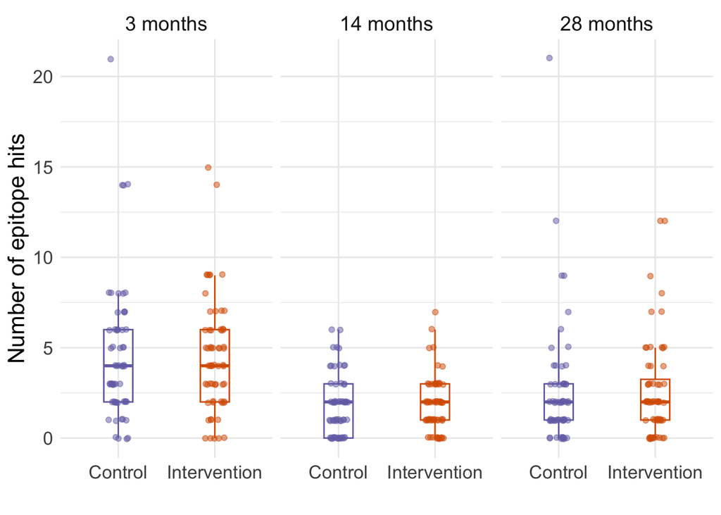

```r
#----------------------------------
# plot epitope hits by visit, group
#----------------------------------
pcols <- brewer.pal(n=3,"Dark2")[c(3,2)]
set.seed(2325) # set seed for reproducible jitter on points
hits1$visit <- as.character(hits1$visit)
hits1 <- hits1 %>%
  mutate(
    visit_2 = case_when(
      visit == "Visit 1" ~ "3 months",
      visit == "Visit 2" ~ "14 months",
      TRUE ~ "28 months"
    ),
    visit_2 = factor(visit_2, levels = c("3 months", "14 months", "28 months"))
  )


plot_hits_by_visit <- ggplot(hits1,
                             aes(x = tx, y = epihits,  color = tx, fill = tx)) +
  facet_grid(.~visit_2) +
  geom_jitter(height=0.05,width=0.1, alpha = 0.5) +
  geom_boxplot(width = 0.3, outlier.shape = NA, fill = NA) +
  scale_color_manual(values=pcols) +
  scale_fill_manual(values=pcols) +
  #scale_color_brewer(palette="Dark2") +
  labs(y = "Number of epitope hits", x = "") +
  theme_minimal() +
  theme(legend.position = "none",
    text = element_text(size = 16),
    strip.text = element_text(size = 14),
    strip.placement = "bottom",   # Moves facet labels outside the plot area
    strip.background = element_blank()
  )

plot_hits_by_visit
```

```r
ggsave(here("output/figures/fig2_rct_n_epitopehits_summary.png"), plot_hits_by_visit, width = 8, height = 6)
```

Summary statistics from the distributions at each visit And then combined for visits 2 and 3 (post maternal IgG)

```r
table1(~epihits |  visit + tx, data=hits1, overall = FALSE)
```

|  | Visit 1 Control (N=60) | Visit 1 Intervention (N=60) | Visit 2 Control (N=60) | Visit 2 Intervention (N=60) | Visit 3 Control (N=60) | Visit 3 Intervention (N=60) |
| --- | --- | --- | --- | --- | --- | --- |
| epihits |  |  |  |  |  |  |
| Mean (SD) | 4.63 (3.84) | 4.52 (3.11) | 1.82 (1.66) | 1.83 (1.54) | 2.60 (3.40) | 2.62 (2.76) |
| Median [Min, Max] | 4.00 [0, 21.0] | 4.00 [0, 15.0] | 2.00 [0, 6.00] | 2.00 [0, 7.00] | 2.00 [0, 21.0] | 2.00 [0, 12.0] |

```r
table1(~epihits |  tx, data=hits1 %>% filter(visit %in% c("Visit 2","Visit 3")), overall = FALSE)
```

|  | Control (N=120) | Intervention (N=120) |
| --- | --- | --- |
| epihits |  |  |
| Mean (SD) | 2.21 (2.69) | 2.23 (2.26) |
| Median [Min, Max] | 2.00 [0, 21.0] | 2.00 [0, 12.0] |

Estimate the difference between groups in epitope hits, comparison using a Mann-Whitney U test (aka Wilcoxon rank sum)

```r
#----------------------------------
# Wilcoxon test
# permute at the cluster level
#----------------------------------

#----------------------------------
# filter data to only >6m observations, per SAP
#----------------------------------
hits2 <- hits1 %>%
  filter(visit %in% c("Visit 2","Visit 3"))

#----------------------------------
# estimate the Wilcoxon rank-sum test statistic
# (the observed statistic)
# the P-value is not quite right, because it
# assumes all observations are independent
# (does not account for repeated measures)
#----------------------------------
wilcox_obs <- wilcox.test(epihits ~ tx, data=hits2, conf.int = TRUE)

# get a list of cluster ids and treatment labels
txlabs <- hits2 %>% select(clusterid, tx) %>% distinct()

#----------------------------------
# permute cluster-level treatments
# store the Wilcoxon rank sum test
# statistic for each permutation
#----------------------------------
# increase to 10,006 for publication quality P-values
npermute <- 10006
permute <- foreach(ii = 1:npermute, .combine = rbind) %dopar% {
  # set seed inside dopar loop for perfect reproducibility
  set.seed(ii)
  txpermute <- txlabs
  txpermute$tx <- sample(txlabs$tx,replace=FALSE)
  di <- hits2 %>% select(-tx) %>% left_join(txpermute,join_by(clusterid))
  wilcoxi <- wilcox.test(epihits ~ tx, data=di)
  return(data.frame(permutation = ii, stat = wilcoxi$statistic))
}

#----------------------------------
# estimate a permutation P-value
# note: the Wilcoxon rank sum test statistic
# has mean m * n / 2, where m and n are
# number of samples in each group. Here, since
# we are permuting clusters it is not exactly equal to m * n / 2
# so simply use the empirical mean of the permutation distribution
# re-center the permutation distribution on zero to
# estimate a 2-sided P-value
#----------------------------------
permute2 <- permute %>%
  mutate(stat0 = stat - mean(stat))

# estimate the P-value as the proportion of
# permutation replicates equal to or more extreme than the observed
# test statistic. use absolute value since it is a symmetric distribution
obs_stat <- wilcox_obs$statistic - mean(permute$stat)
permute_p <- mean( abs(permute2$stat0) >= abs(obs_stat) )
cat(paste0("\nPermutation P-value for Intervention vs Control (",format(npermute,big.mark=",")," permutations): ", sprintf("%1.2f",permute_p),"\n"))
```

```
##
## Permutation P-value for Intervention vs Control (10,006 permutations): 0.96
```

As a quick diagnostic, always check the permutation distribution

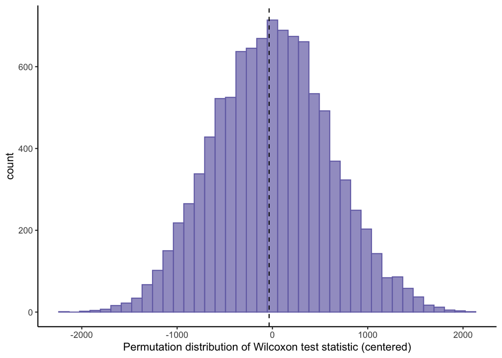

```r
#----------------------------------
# plot the permutation distribution
# of the test statistic and the
# observed value
#----------------------------------
plot_permute <- ggplot(data=permute2, aes(x=stat0)) +
  geom_histogram(bins=40, color = pcols[1], fill = pcols[1], alpha=0.7) +
  geom_vline(xintercept=obs_stat, lty="dashed") +
  labs(x = "Permutation distribution of Wilcoxon test statistic (centered)")+
  theme_classic()

plot_permute
```

# Seroprevalence

Compare groups using seroprevalence. Define a sample as seropositive to a pathogen if it had ≥2 epitope hits to that pathogen.

```r
#----------------------------------
# identify seropositive samples
# as those with >= 2 epitope hits
# to the pathogen
#----------------------------------
serop1 <- hits1 %>%
  mutate(seropos = ifelse(epihits>=2,1,0))
```

Estimate mean and 95% CIs for seroprevalence at each visit bootstrap resample clusters to get the correct 95% CIs

```r
#----------------------------------
# estimate mean seroprev by visit and
# group.
#----------------------------------
est_mu <- serop1 %>%
  group_by(visit,tx) %>%
  summarize(nobs = n(),
            npos = sum(seropos),
            .groups = "drop") %>%
  mutate(seroprev = npos/nobs)

#----------------------------------
# Bootstrap resample clusters
# to get the correct 95% CIs that account
# for repeated measures
#----------------------------------
set.seed(89326)
# create a bootstrap sampling frame
# resampling clusters with replacement
breps <- 1000
clids <- unique(serop1$clusterid)
bsamp <- matrix(sample(clids, size = breps*length(clids),replace=TRUE),nrow=length(clids),ncol=breps)

boot <- foreach(bi = 1:breps, .combine = rbind) %dopar% {
  # draw the bootstrap dataset,
  # due to repeated measures in the seroprev dataset, this
  # is likely a many-to-many join since clusters could be sampled
  # more than once! (if not bootstrapping, would be one-to-many)
  di <- left_join(data.frame(clusterid = bsamp[,bi]), serop1,
                  join_by(clusterid), relationship = "many-to-many") %>%
    group_by(visit,tx) %>%
    summarize(nobs = n(),
              npos = sum(seropos),
              .groups = "drop") %>%
    mutate(seroprev = npos/nobs) %>%
    mutate(brep=bi)
  return(di[c("brep","visit","tx","seroprev")])
}

#----------------------------------
# estimate percentile 95% CIs for
# the seroprevalence by visit and group
# identify the 2.5% and 97.5% tiles
# of the bootstrap distribution
#----------------------------------
boot_ci <- boot %>%
  group_by(visit, tx) %>%
  mutate(min95 = quantile(seroprev,probs = 0.025),
         max95 = quantile(seroprev,probs = 0.975)) %>%
  slice(1) %>%
  select(visit,tx,min95,max95)
# join to the means
est_mu_visit <- est_mu %>%
  left_join(boot_ci, join_by(visit, tx))
```

```r
kbl(est_mu_visit, digits=3, caption = "Seroprevalence by visit and treatment group") %>%
  kable_styling(bootstrap_options = "striped")
```

Seroprevalence by visit and treatment group

| visit | tx | nobs | npos | seroprev | min95 | max95 |
| --- | --- | --- | --- | --- | --- | --- |
| Visit 1 | Control | 60 | 51 | 0.850 | 0.750 | 0.933 |
| Visit 1 | Intervention | 60 | 51 | 0.850 | 0.766 | 0.930 |
| Visit 2 | Control | 60 | 31 | 0.517 | 0.403 | 0.643 |
| Visit 2 | Intervention | 60 | 32 | 0.533 | 0.390 | 0.667 |
| Visit 3 | Control | 60 | 33 | 0.550 | 0.429 | 0.662 |
| Visit 3 | Intervention | 60 | 36 | 0.600 | 0.459 | 0.731 |

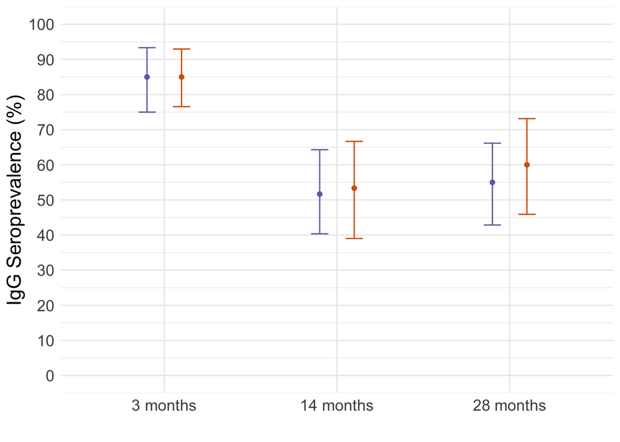

```r
#----------------------------------
# plot seroprevalence by visit
# and group
#----------------------------------
pcols <- brewer.pal(3,"Dark2")[c(3,2)]
wrapped_labels <- str_wrap(c("3 months",
                            "14 months",
                              "28 months"), width = 20)
plot_seroprev_visit <- ggplot(est_mu_visit, aes(x = visit, color = tx)) +
  geom_errorbar(aes(ymin=min95,ymax=max95), position=position_nudge(x=c(-0.1,0.1)), width=0.1) +
  geom_point(aes(y=seroprev), position=position_nudge(x=c(-0.1,0.1))) +
  scale_color_manual(values=pcols) +
  scale_y_continuous(breaks=seq(0,1,by=0.1),labels=seq(0,1,by=0.1)*100) +
  scale_x_discrete(labels = wrapped_labels) +
  coord_cartesian(ylim = c(0,1)) +
  labs(x="",y="IgG Seroprevalence (%)") +
  theme_minimal() +
  theme(text = element_text(size = 16),
        legend.position = "none")

plot_seroprev_visit
```

```r
ggsave(here("output/figures/fig2_rct_seroprev_summary.png"), plot_seroprev_visit, width = 8, height = 6)
```

Collapse data from visits 2 and 3 per the pre-specified analysis plan. Estimate means, 95% CIs, along with differences and ratios

```r
#----------------------------------
# limit to visits 2, 3
#----------------------------------
serop2 <- serop1 %>%
  filter(visit %in% c("Visit 2","Visit 3"))
#----------------------------------
# estimate mean seroprev by
# group.  This and bootstrap below
# is identical to estimation of means
# above, but does not stratify by visit
# (pools data over visits 2, 3)
#----------------------------------
ests_by_tx <- serop2 %>%
  group_by(tx) %>%
  summarize(nobs = n(),
            npos = sum(seropos),
            .groups = "drop") %>%
  mutate(seroprev = npos/nobs)
```

```r
#----------------------------------
# estimate the difference in
# seroprevalence using a linear-binomial model
# with robust SEs at the cluster level
# save estimates, 95% CI, and P-value
#----------------------------------
fit_pd <- glm(seropos ~ tx, data=serop2, family=binomial(link="identity"))
(fit_pd_rb <- coeftest(fit_pd, vcov. = vcovCL(fit_pd, cluster=serop2$clusterid)))
```

```
##
## z test of coefficients:
##
##                Estimate Std. Error z value Pr(>|z|)
## (Intercept)    0.533333   0.047307 11.2739   <2e-16 ***
## txIntervention 0.033333   0.070792  0.4709   0.6377
## ---
## Signif. codes:  0 '***' 0.001 '**' 0.01 '*' 0.05 '.' 0.1 ' ' 1
```

```r
pd <- fit_pd_rb[2,1]
pd_se <- fit_pd_rb[2,2]
pd_min95 <- pd - 1.96*pd_se
pd_max95 <- pd + 1.96*pd_se
pd_p <- fit_pd_rb[2,4]

#----------------------------------
# estimate robust 95% CIs for
# seroprevalence by group from
# the model fit. Equivalent to
# bootstrap above (by visit), but faster
#----------------------------------
mu0 <- fit_pd_rb[1,1]
mu0_se <- fit_pd_rb[1,2]
mu0_min95 <- mu0 - 1.96*mu0_se
mu0_max95 <- mu0 + 1.96*mu0_se
mu1 <- fit_pd_rb[1,1]+fit_pd_rb[2,1]
# SE of mu1= sqrt of variance of the linear combination of intercept + tx
# the linear combination of coefficiencts is matrix-multiplied against
# the robust var-covariance matrix estimated above
mu1_se <- sqrt( t(c(1,1)) %*% vcovCL(fit_pd, cluster=serop2$clusterid) %*% c(1,1) )
mu1_min95 <- mu1 - 1.96*mu1_se
mu1_max95 <- mu1 + 1.96*mu1_se

#----------------------------------
# estimate the ratio in
# seroprevalence using a log-binomial model
# with robust SEs at the cluster level
#----------------------------------
fit_pr <- glm(seropos ~ tx, data=serop2, family=binomial(link="log"))
(fit_pr_rb <- coeftest(fit_pr, vcov. = vcovCL(fit_pr, cluster=serop2$clusterid)))
```

```
##
## z test of coefficients:
##
##                 Estimate Std. Error z value  Pr(>|z|)
## (Intercept)    -0.628609   0.088700 -7.0869 1.372e-12 ***
## txIntervention  0.060625   0.128472  0.4719     0.637
## ---
## Signif. codes:  0 '***' 0.001 '**' 0.01 '*' 0.05 '.' 0.1 ' ' 1
```

```r
logpr <- fit_pr_rb[2,1]
logpr_se <- fit_pr_rb[2,2]
pr <- exp(logpr)
pr_min95 <- exp(logpr - 1.96*logpr_se)
pr_max95 <- exp(logpr + 1.96*logpr_se)
pr_p <- fit_pr_rb[2,4]


#----------------------------------
# combine results into a single
# data frame
#----------------------------------
ests_by_tx2 <- ests_by_tx
ests_by_tx2$seroprev_min95 <- c(mu0_min95,mu1_min95)
ests_by_tx2$seroprev_max95 <- c(mu0_max95,mu1_max95)
ests_by_tx2$pd <- c(NA,pd)
ests_by_tx2$pd_min95 <- c(NA,pd_min95)
ests_by_tx2$pd_max95 <- c(NA,pd_max95)
ests_by_tx2$pd_p <- c(NA,pd_p)
ests_by_tx2$pr <- c(NA,pr)
ests_by_tx2$pr_min95 <- c(NA,pr_min95)
ests_by_tx2$pr_max95 <- c(NA,pr_max95)
ests_by_tx2$pr_p <- c(NA,pr_p)
```

```r
#----------------------------------
# create formatted versions
#----------------------------------
ests_by_tx3 <- ests_by_tx2 %>%
  mutate(seroprev_print = paste0(sprintf("%1.1f",seroprev*100),"% (",
                                 sprintf("%1.1f",seroprev_min95*100),"%, ",
                                 sprintf("%1.1f",seroprev_max95*100),"%)")
  ) %>%
  mutate(pd_print = paste0(sprintf("%1.1f",pd*100),"% (",
                                 sprintf("%1.1f",pd_min95*100),"%, ",
                                 sprintf("%1.1f",pd_max95*100),"%)")
  ) %>%
  mutate(pr_print = paste0(sprintf("%1.1f",pr)," (",
                                 sprintf("%1.1f",pr_min95),", ",
                                 sprintf("%1.1f",pr_max95),")")
  ) %>%
  select(tx,nobs,npos,seroprev_print,pd_print,pr_print,pr_p)

# set formatted print vals to missing again for cleaner display
ests_by_tx3$pd_print[ests_by_tx$tx=="Control"] <- NA
ests_by_tx3$pr_print[ests_by_tx$tx=="Control"] <- NA

options(knitr.kable.NA = '')
kbl(ests_by_tx3, digits=3, caption = "Seroprevalence, comparison of groups. Estimates based on 60 children in each group measured twice at median ages 14 and 28 months. 95% CIs and P-values account for repeated measures within children and clusters using robust SEs", col.names = c("Group","N","N pos","Seroprevalence (95% CI)","PD (95% CI)","PR (95% CI)","P-value")) %>%
  kable_styling(bootstrap_options = "striped")
```

Seroprevalence, comparison of groups. Estimates based on 60 children in each group measured twice at median ages 14 and 28 months. 95% CIs and P-values account for repeated measures within children and clusters using robust SEs

| Group | N | N pos | Seroprevalence (95% CI) | PD (95% CI) | PR (95% CI) | P-value |
| --- | --- | --- | --- | --- | --- | --- |
| Control | 120 | 64 | 53.3% (44.1%, 62.6%) |  |  |  |
| Intervention | 120 | 68 | 56.7% (46.3%, 67.0%) | 3.3% (-10.5%, 17.2%) | 1.1 (0.8, 1.4) | 0.637 |